# Unblinded_AveLength

Jaylin Lowe, Xinhe Wu, and Yiheng Xiang

2025-02-20

## Average Name Length

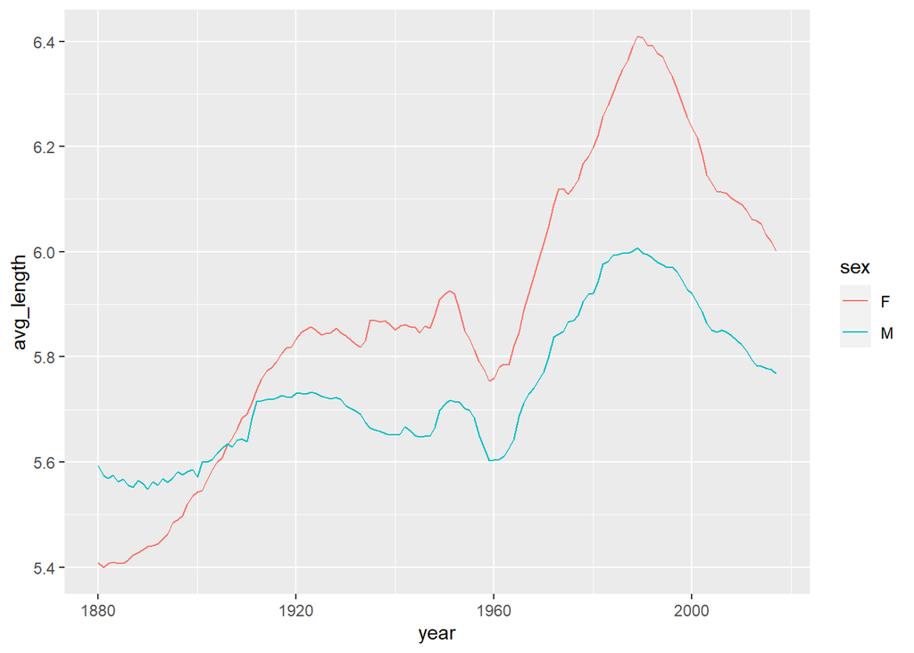

The graph below shows the original female and male name data versus the fitted values (dotted line) from the quadratic polynomial:

```
##
## Call:
## tslm(formula = ts_female ~ trend + I(trend^2))
##
## Residuals:
##       Min        1Q    Median        3Q       Max
## -0.249907 -0.056198 -0.007336  0.064699  0.271726
##
## Coefficients:
##               Estimate Std. Error t value Pr(>|t|)
## (Intercept)  5.353e+00  3.001e-02 178.346  < 2e-16 ***
## trend        1.079e-02  9.969e-04  10.825  < 2e-16 ***
## I(trend^2)  -3.322e-05  6.947e-06  -4.782 4.48e-06 ***
## ---
## Signif. codes:  0 '***' 0.001 '**' 0.01 '*' 0.05 '.' 0.1 ' ' 1
##
## Residual standard error: 0.1158 on 135 degrees of freedom
## Multiple R-squared:  0.8269, Adjusted R-squared:  0.8243
## F-statistic: 322.5 on 2 and 135 DF,  p-value: < 2.2e-16
```

```
##
## Call:
## tslm(formula = ts_male ~ trend + I(trend^2))
##
## Residuals:
##      Min       1Q   Median       3Q      Max
## -0.16828 -0.05264 -0.00833  0.05745  0.16053
##
## Coefficients:
##               Estimate Std. Error t value Pr(>|t|)
## (Intercept)  5.546e+00  2.098e-02 264.385  < 2e-16 ***
## trend        2.907e-03  6.967e-04   4.172 5.37e-05 ***
## I(trend^2)  -1.583e-06  4.855e-06  -0.326    0.745
## ---
## Signif. codes:  0 '***' 0.001 '**' 0.01 '*' 0.05 '.' 0.1 ' ' 1
##
## Residual standard error: 0.08095 on 135 degrees of freedom
## Multiple R-squared:  0.6413, Adjusted R-squared:  0.636
## F-statistic: 120.7 on 2 and 135 DF,  p-value: < 2.2e-16
```

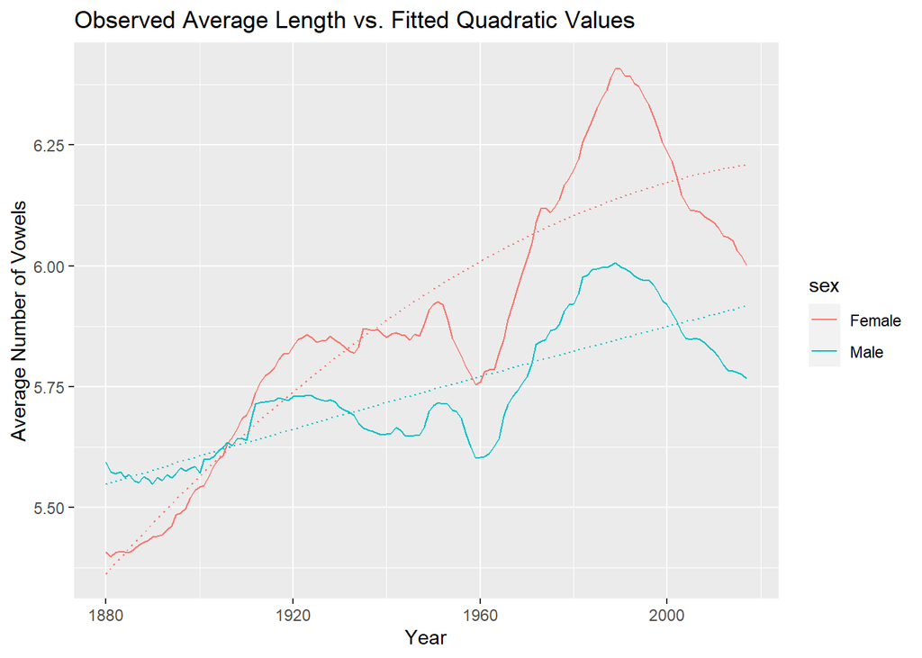

Since the p‐value for the I(trend^2) term is below 0.05 in the female trend model, we retain the quadratic term. In contrast, for the male data, the p‐value for I(trend^2) exceeds 0.05, so we discard the quadratic term, keep only the linear term, and refit the model.

```
##
## Call:
## tslm(formula = ts_male ~ trend)
##
## Residuals:
##      Min       1Q   Median       3Q      Max
## -0.16601 -0.05021 -0.01047  0.05879  0.16044
##
## Coefficients:
##              Estimate Std. Error t value Pr(>|t|)
## (Intercept) 5.5508995  0.0138115  401.90   <2e-16 ***
## trend       0.0026868  0.0001724   15.58   <2e-16 ***
## ---
## Signif. codes:  0 '***' 0.001 '**' 0.01 '*' 0.05 '.' 0.1 ' ' 1
##
## Residual standard error: 0.08068 on 136 degrees of freedom
## Multiple R-squared:  0.641,  Adjusted R-squared:  0.6384
## F-statistic: 242.8 on 1 and 136 DF,  p-value: < 2.2e-16
```

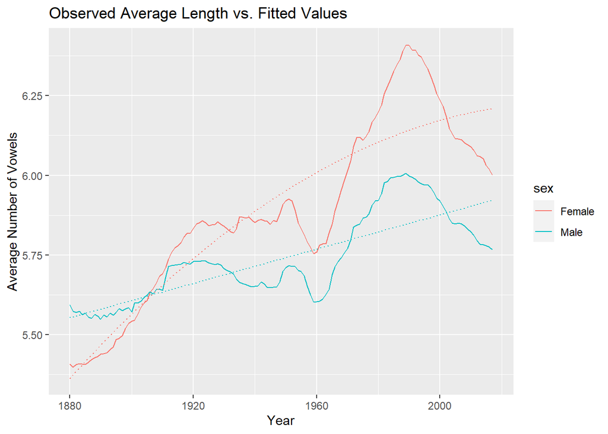

Next, we will perform a spectral analysis on the residues of male and female.

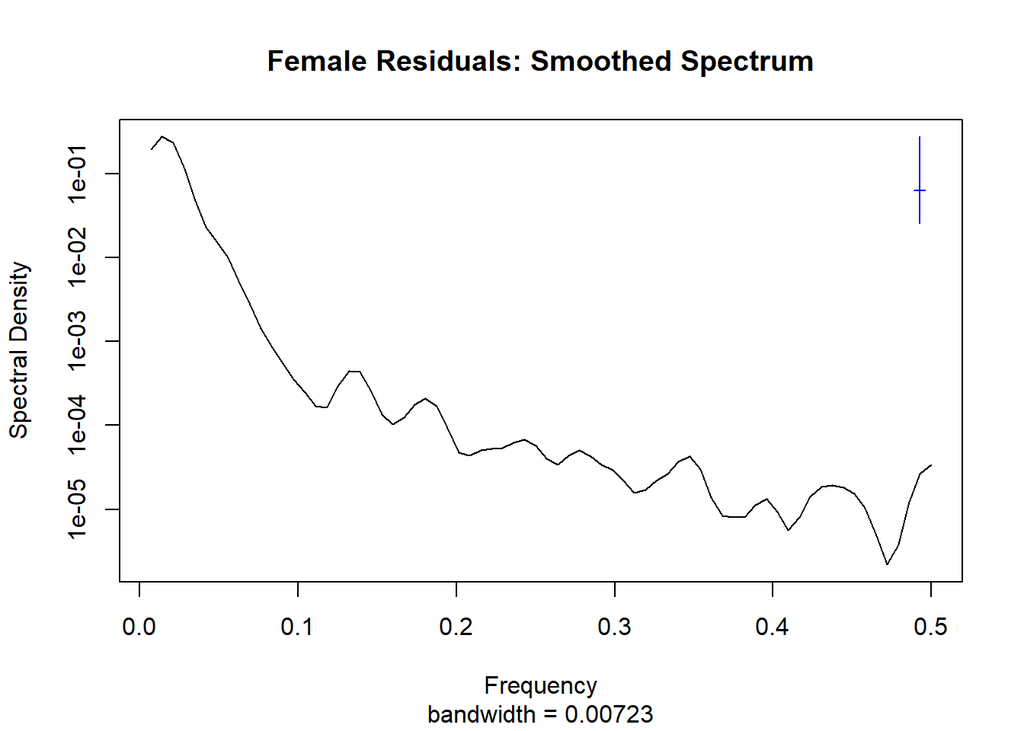

```
## The peak frequency of female:  0.01388889
```

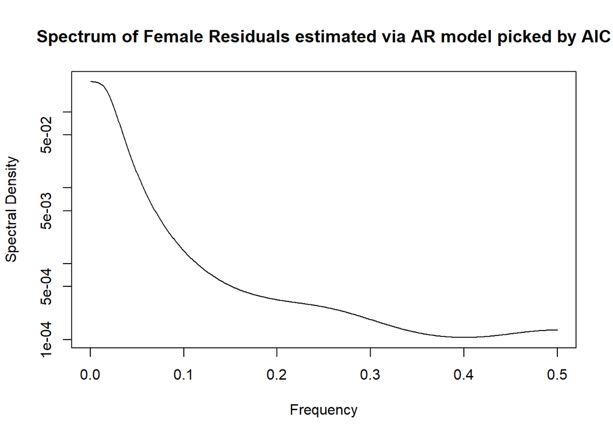

```
## The peak frequency of female using AIC:  0
```

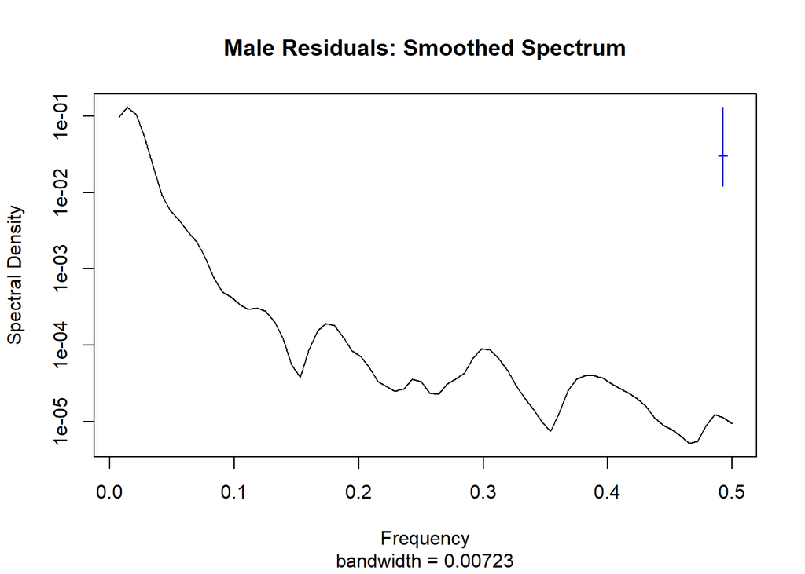

```
## The peak frequency of male:  0.01388889
```

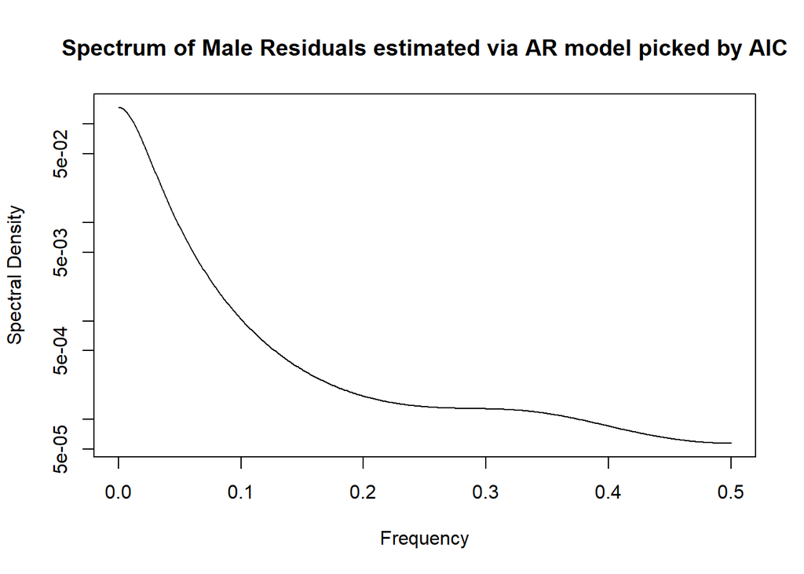

```
## The peak frequency of male using AIC:  0
```

The highest frequency in the smoothed female and male residuals are both 0.01389, indicating that there is period $T=1/\omega\approx72$ years. However, we only have total record of 138 years, which means in such a super long cycle of 72 years, we can only see at most less than two complete ‘ups and downs’. Therefore, it is very difficult to reliably verify it.

And inspired by a previous project<sup>[1]</sup>, when we use AIC to select the best estimators, the peak frequency are both 0 in male and female residuals, leading to an infinite period. Consequently, there are no periodic behavior in both male and female residuals.

We next fit $ARMA(p,q)$ models to the residuals from each trend model—*quadratic* for female and *linear* for male. For each case, we consider $p \in \{0,\dots,5\}$ and $q \in \{0,\dots,5\}$, and then calculate the AIC of every fitted model. As shown in the class<sup>[2]</sup>, we insert `NA` if certain $(p,q)$ pairs fail to converge or emit warnings. We use `arima2`<sup>[3]</sup> to help avoid optimization pitfalls.

#### Female Residuals (Quadratic Trend)

The polynomial is
$$Y_n \;=\;\alpha \;+\;\beta_1\,X_n \;+\;\beta_2\,X_n^2
\;+\;\varepsilon_n,$$
where we estimated $\alpha = 5.353,\; \beta_1 = 0.01079,\; \beta_2 = -3.322\times 10^{-5}$. Here, $\varepsilon_n$ is modeled by a Gaussian $ARMA(p,q)$. The AIC values from a grid of $(p,q)$ reveal which ARMA specification best fits the **female** residuals.

#### Male Residuals (Linear Trend)

In contrast, for the **male** series we use a simpler model,
$$Y_n \;=\;\alpha \;+\;\beta_1\,X_n \;+\;\varepsilon_n,$$
with $\alpha=5.5509$ and $\beta_1=0.0026868$. Again, $\varepsilon_n$ follows an $ARMA(p,q)$. We search over the same grid of $p,q$ and record AIC values, then select the $(p,q)$ combination yielding the minimum AIC for the male residuals.

Below, we present the AIC tables for both **female** and **male** residuals. From these, we pick the ARMA model (i.e., the $(p,q)$ pair) with the lowest AIC in each case, and proceed with further analysis or diagnostics accordingly.

[output not shown]

```
## [1] 3 3
## <simpleError in arima2::arima(data, order = c(p, D, q)): non-stationary AR part from CSS>
## [1] 5 4
## <simpleWarning in arima2::arima(data, order = c(p, D, q)): possible convergence problem: optim gave code = 1>
```

AIC Table for Detrended Female Ave Length Run Data

|  | MA0 | MA1 | MA2 | MA3 | MA4 | MA5 |
| --- | --- | --- | --- | --- | --- | --- |
| AR0 | -202.3654 | -371.8514 | -516.7669 | -602.9879 | -665.3339 | -708.3743 |
| AR1 | NA | -790.1622 | -810.0762 | -816.2676 | -823.5416 | -826.1206 |
| AR2 | -837.5079 | -840.3016 | -841.4369 | -841.6460 | -841.4593 | -842.3246 |
| AR3 | -838.2594 | NA | -845.9431 | NA | NA | -842.9951 |
| AR4 | -839.8502 | -845.8986 | -846.9796 | -844.7070 | -844.3762 | -844.6189 |
| AR5 | -839.1964 | -844.5868 | -844.9876 | NA | NA | NA |

AIC Table for Detrended Male Ave Length Run Data

|  | MA0 | MA1 | MA2 | MA3 | MA4 | MA5 |
| --- | --- | --- | --- | --- | --- | --- |
| AR0 | -301.1391 | -471.6996 | -588.2962 | -665.5443 | -721.4425 | -750.9901 |
| AR1 | -790.0772 | -823.1253 | -826.5107 | -838.1213 | -837.0358 | -836.4054 |
| AR2 | -836.0624 | -846.1305 | -850.9766 | -844.8755 | -854.2596 | -852.2854 |
| AR3 | -839.2483 | -851.7415 | -850.6629 | NA | -852.2837 | -852.8120 |
| AR4 | -847.2840 | -846.1720 | -845.2589 | -850.1230 | -853.0144 | -852.2944 |
| AR5 | -845.5073 | -844.5384 | -844.8818 | -851.4555 | NA | -850.1979 |

We are going to avoid $p+q\geq5$ situations (in case of overfitting), and thus take $\text{ARMA}(2,2)$ model (AIC: -841.4369) for female residuals and $\text{ARMA}(3,1)$ model (AIC: -851.7415) for male residuals from the above result.

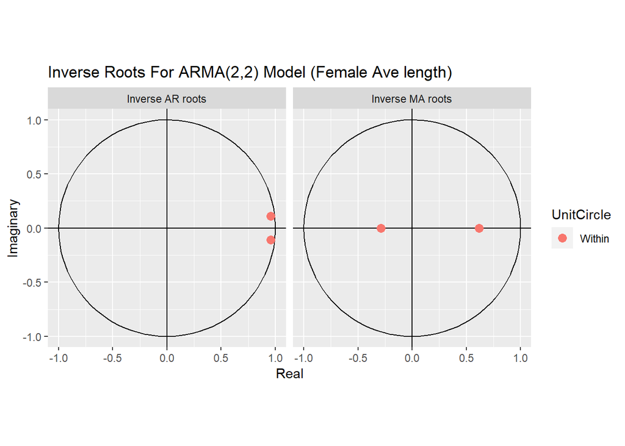

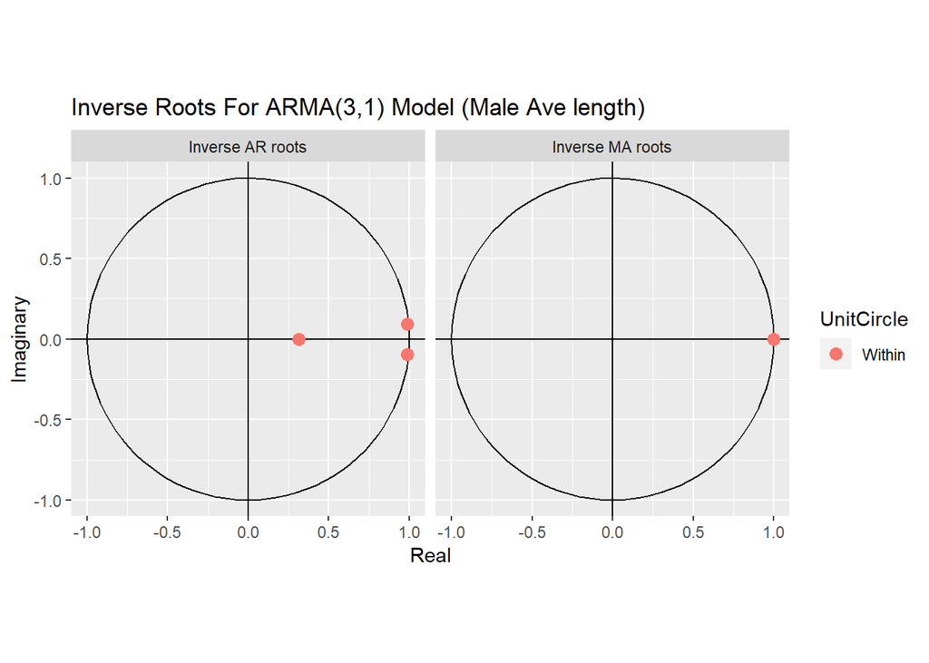

After we check the plot of inverse roots, we find that for the female model, all the points are inside the boundary of the unit circle (although some points are close to the boundary, we still consider it within the circle), but for the male model, some of the roots are on the border of the unit circle. And this is also true for the $\text{ARMA}(2,2)$ model.

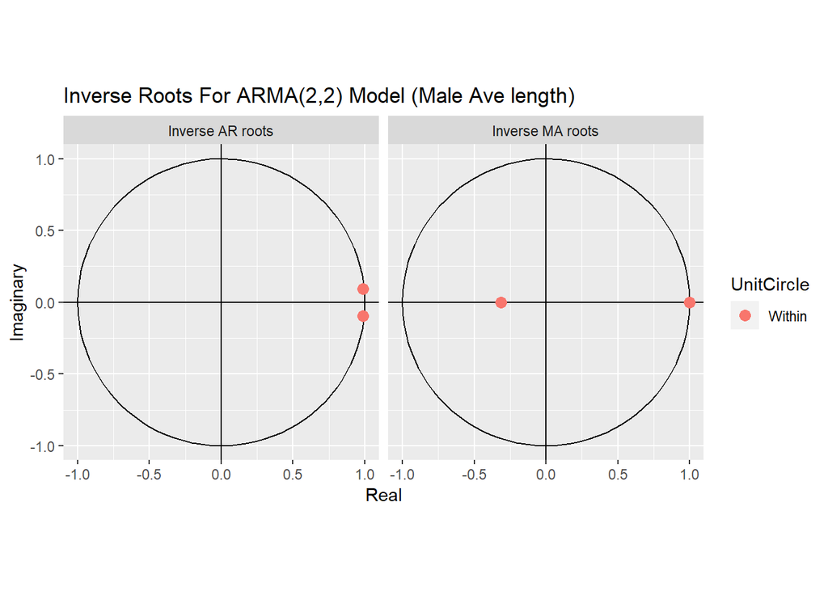

Therefore, we finally decide to take $\text{ARMA}(4,0)$ model (AIC: -847.2840) for the male residuals, since all the points are inside the boundary of the unit circle.

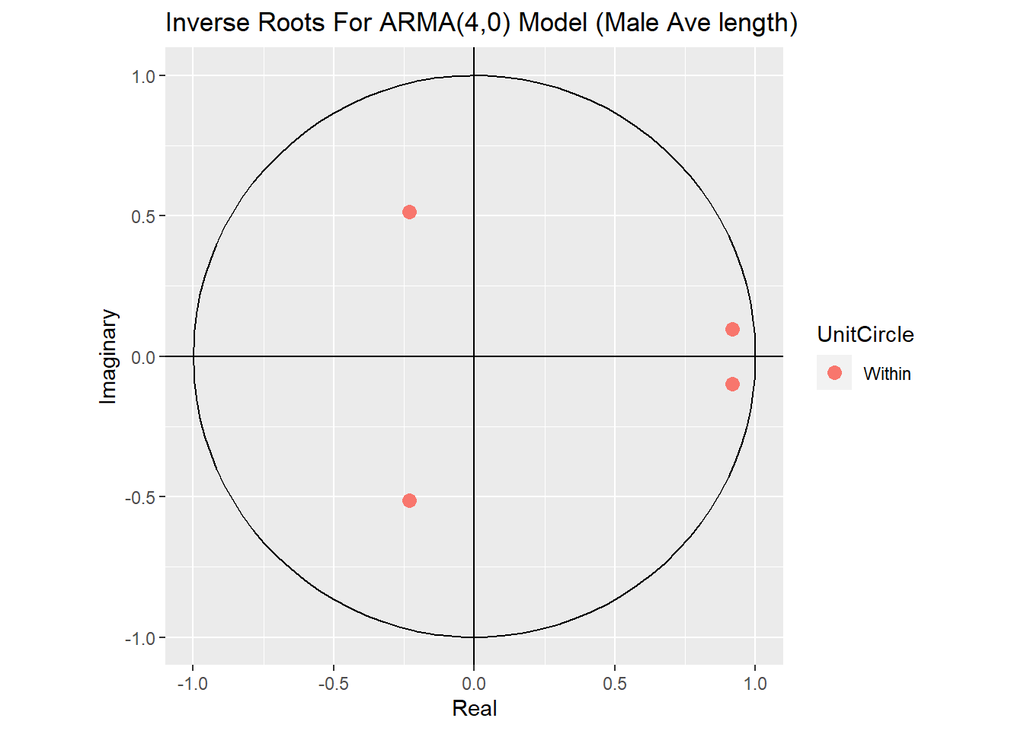

And the $\text{ARMA}(2,2)$ model for female residuals, the $\text{ARMA}(4,0)$ model for male residuals are both consistent with the `auto.arima` function from the `forcast` package<sup>[4]</sup>. Consequently, we decide to take these two models as our final models for the male and female residuals.

```
## Series: resid_female
## ARIMA(2,0,2) with zero mean
##
## Coefficients:
##          ar1      ar2      ma1      ma2
##       1.9166  -0.9304  -0.3339  -0.1777
## s.e.  0.0457   0.0451   0.1031   0.1029
##
## sigma^2 = 0.0001191:  log likelihood = 426.71
## AIC=-843.41   AICc=-842.96   BIC=-828.78
##
## Training set error measures:
##                         ME       RMSE         MAE      MPE     MAPE      MASE
## Training set -0.0002391276 0.01075398 0.008409678 3.633532 29.66217 0.6163374
##                     ACF1
## Training set 0.002760282
```

```
## Series: resid_male
## ARIMA(4,0,0) with zero mean
##
## Coefficients:
##          ar1      ar2     ar3     ar4
##       1.3719  -0.3196  0.1884  -0.270
## s.e.  0.0825   0.1434  0.1430   0.083
##
## sigma^2 = 0.000115:  log likelihood = 429.63
## AIC=-849.26   AICc=-848.81   BIC=-834.63
##
## Training set error measures:
##                         ME       RMSE         MAE      MPE     MAPE      MASE
## Training set -0.0002973579 0.01056926 0.008024159 43.43996 79.35546 0.7858266
##                     ACF1
## Training set 0.006559035
```

Next, we plot the forecasted values for the next 20 years:

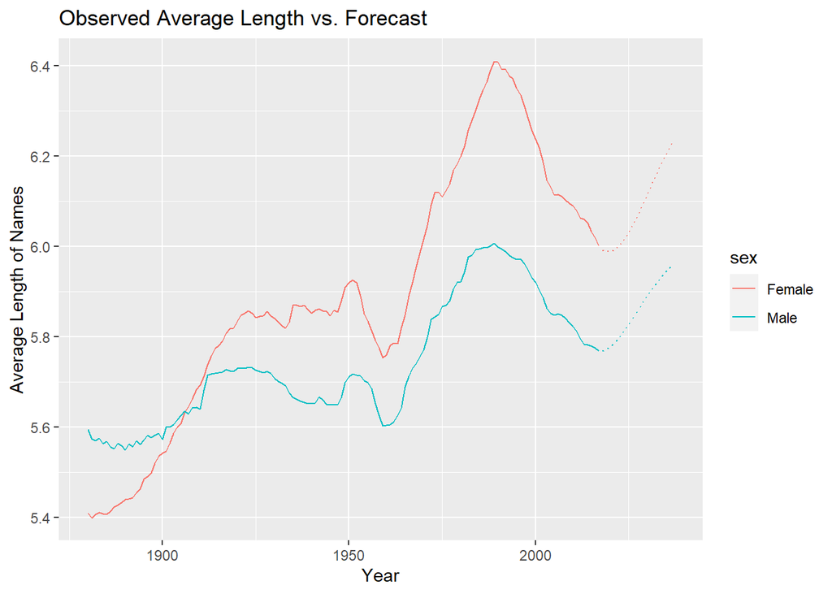

From the plot, we can see that both male and female curves show a long-run rising tendency, short-term fluctuations, and a modest upward forecast beyond the last observed year.

Finally, We will use the `checkresiduals` function to help us determine if we are overfitting the data or leaving out useful information is by checking the residuals.

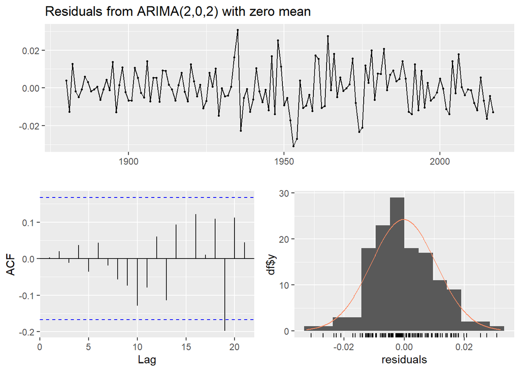

```
##
##  Ljung-Box test
##
## data:  Residuals from ARIMA(2,0,2) with zero mean
## Q* = 4.6382, df = 6, p-value = 0.591
##
## Model df: 4.   Total lags used: 10
```

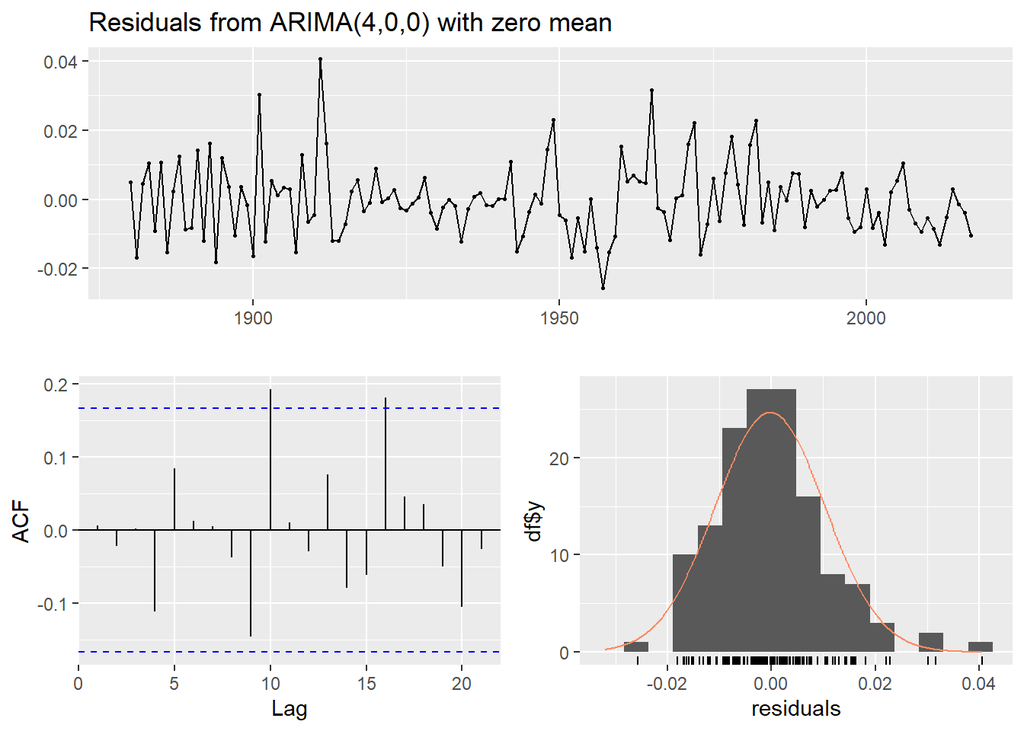

```
##
##  Ljung-Box test
##
## data:  Residuals from ARIMA(4,0,0) with zero mean
## Q* = 11.902, df = 6, p-value = 0.0642
##
## Model df: 4.   Total lags used: 10
```

#### Female Residuals from $\text{ARMA}(2,2)$

- The residuals fluctuate around zero without any visible trend or large shifts over time. No obvious clustering of positive or negative errors.
- Nearly all autocorrelations fall within the $\pm2$ SE bounds (blue dashed lines), suggesting no strong leftover serial correlation.
- The residual distribution appears roughly symmetric and bell‐shaped, indicating approximate normality.
- Since p-value=0.591 in the Ljung-Box test<sup>[5]</sup>, we fail to reject the null of “no autocorrelation,” implying the residuals are effectively white noise.

Therefore, the $\text{ARMA}(2,2)$ model for the female series exhibits no major signs of leftover structure in the residuals, and they appear approximately normal. This indicates a good fit.

#### Male Residuals from $\text{ARMA}(4,0)$

- Also mean‐reverting around zero, with no major pattern. Slightly more spiky at certain points, but nothing glaring.
- Most lags are within the $\pm2$ SE bounds, though a couple of marginal lags exist. Still, no glaring sign of strong correlation.
- The residual distribution is near-normal, perhaps slightly skewed in the tails, but not too severe.
- Since p-value=0.0642 in the Ljung-Box test, we fail to reject the null of “no autocorrelation,” implying the residuals are effectively white noise.

Therefore, the $\text{ARMA}(4,0)$ fit for the male series also has residuals that mostly behave like white noise, although the Ljung–Box test’s p‐value is a bit borderline (0.0642). Overall, it suggests adequate fit.

1. *Midterm project: Analysis of BTC and DOGE*. (2024). https://ionides.github.io/531w24/midterm_project/project02/blinded.html

2. Ionides, E. (2025). *Notes for STATS/DATASCI 531, Modeling and Analysis of Time Series Data*. https://ionides.github.io/531w25/

3. Wheeler, J., McAllister, N., & Sylvertooth, D. (2024). *arima2: Likelihood based inference for ARIMA modeling*. https://CRAN.R-project.org/package=arima2

4. Hyndman, R. J., & Khandakar, Y. (2008). Automatic time series forecasting: The forecast package for R. *Journal of Statistical Software*, *27*(3), 1–22. https://doi.org/10.18637/jss.v027.i03

5. Ljung, G. M., & Box, G. E. P. (1978). On a measure of lack of fit in time series models. *Biometrika*, *65*(2), 297–303. https://doi.org/10.1093/biomet/65.2.297